# Marjum 2026-07 — Joint Antenna + Transmitter Posterior: MCMC Review

## 3b. Transmitter posterior — the first one computed for this target

Compare against the deterministic product: `[1652.198, 2025.104, 1684.384]` m with a **±1.5 m hard bracket**, and against the independent-pair solution `[1652.410, 2025.238, 1684.742]` m obtained from cameras 2210 and 2211 alone — the only two transmitter views whose poses are *not* fitted against the transmitter.

**Read the width of this posterior with care.** Six of the eight transmitter-labelled views are conditioned on the transmitter, and two of them (2199, 2203) sit only ~3 m from it, so they pin it with enormous angular leverage while contributing no independent information. A narrow posterior here is therefore *not* evidence of a well-determined transmitter; it is what conditioning looks like. The ±1.5 m bracket spans several fit generations and captures methodological spread this posterior structurally cannot see.

```python
if JOINT and 'transmitter' in conv:
    t = conv['transmitter']
    det_tx = np.array([1652.198, 2025.104, 1684.384])     # bracketed product
    ind_tx = np.array([1652.410, 2025.238, 1684.742])     # 2210+2211 alone
    print(f"{'':14s}{'E':>12s}{'N':>12s}{'U':>12s}")
    for lab in ('mean', 'sd', 'q05', 'q50', 'q95'):
        print(f'{lab:14s}' + ''.join(f'{v:12.3f}' for v in t[lab]))
    print(f"{'Rhat':14s}" + ''.join(f'{v:12.4f}' for v in t['rhat']))
    print(f"{'ESS bulk':14s}" + ''.join(f'{v:12.0f}' for v in t['ess_bulk']))
    print()
    print(f"{'bracketed':14s}" + ''.join(f'{v:12.3f}' for v in det_tx) + '   (+/-1.5 m hard bracket)')
    print(f"{'indep pair':14s}" + ''.join(f'{v:12.3f}' for v in ind_tx) + '   (2210+2211 alone)')
    m = np.array(t['mean'])
    print(f"{'offset vs bracketed':20s} {np.linalg.norm(m-det_tx):.3f} m"
          f"   vs independent pair {np.linalg.norm(m-ind_tx):.3f} m")
    print(f"posterior 90% widths (m): " + ', '.join(f'{hi-lo:.3f}' for lo, hi in zip(t['q05'], t['q95'])))
    print()
    print('Per-chain transmitter means:')
    for i, mm in enumerate(t['per_chain_mean']):
        print(f'  chain {i}: {mm}')
else:
    print('antenna-only run: no transmitter sampled')
```

```
                         E           N           U
mean              1652.867    2025.675    1683.414
sd                   0.330       0.244       0.143
q05               1652.401    2025.316    1683.189
q50               1652.832    2025.652    1683.405
q95               1653.473    2026.115    1683.655
Rhat                1.9770      1.4550      1.5240
ESS bulk                11          16          15

bracketed         1652.198    2025.104    1684.384   (+/-1.5 m hard bracket)
indep pair        1652.410    2025.238    1684.742   (2210+2211 alone)
offset vs bracketed  1.309 m   vs independent pair 1.471 m
posterior 90% widths (m): 1.072, 0.800, 0.466

Per-chain transmitter means:
  chain 0: [1652.851, 2025.744, 1683.488]
  chain 1: [1653.062, 2025.789, 1683.578]
  chain 2: [1652.784, 2025.475, 1683.443]
  chain 3: [1652.587, 2025.529, 1683.535]
  chain 4: [1652.477, 2025.462, 1683.361]
  chain 5: [1653.348, 2025.867, 1683.294]
  chain 6: [1652.882, 2025.646, 1683.301]
  chain 7: [1652.946, 2025.886, 1683.308]
```

### 3c. How inconsistent are the manual picks?

Both targets carry an excess-scatter parameter: the extra pixel scatter, beyond the assumed 3 px labelling precision, needed to reconcile all the picks of that target. It is estimated, not assumed. A large value is the model reporting that the picks disagree with each other by more than the stated precision — which for the transmitter is exactly the known 2210/2211-vs-conditioned-six group disagreement, now measured rather than argued about.

```python
for key, label in (('antenna_scatter_px', 'antenna'), ('transmitter_scatter_px', 'transmitter')):
    if key in conv:
        s = conv[key]
        print(f"{label:12s} excess scatter {s['mean']:6.2f} px  (sd {s['sd']:5.2f}, "
              f"90% {s['q05']:5.2f}-{s['q95']:5.2f})  Rhat {s['rhat']:.3f}  ESS {s['ess_bulk']:.0f}")
print()
print('Assumed base labelling precision: 3 px. Excess is added in quadrature.')
```

```
antenna      excess scatter  30.24 px  (sd  3.46, 90% 24.94-36.28)  Rhat 1.143  ESS 35
transmitter  excess scatter   7.26 px  (sd  5.35, 90%  0.63-17.85)  Rhat 1.515  ESS 15

Assumed base labelling precision: 3 px. Excess is added in quadrature.
```

## 4. Per-image trace plots — one set of axes per camera

Each camera gets its own row of axes: its seven sampled coordinates (`e, n, u` in metres, `th, ph, ti` in radians, `log f`), with all chains overlaid *within* each panel. Cameras are never overlaid on one another. Panel titles carry that coordinate's Rhat, so a badly-mixing camera is visible without cross-referencing the table. Traces are thinned and rasterized to keep the review artifacts a sane size; thinning affects only the rendering.

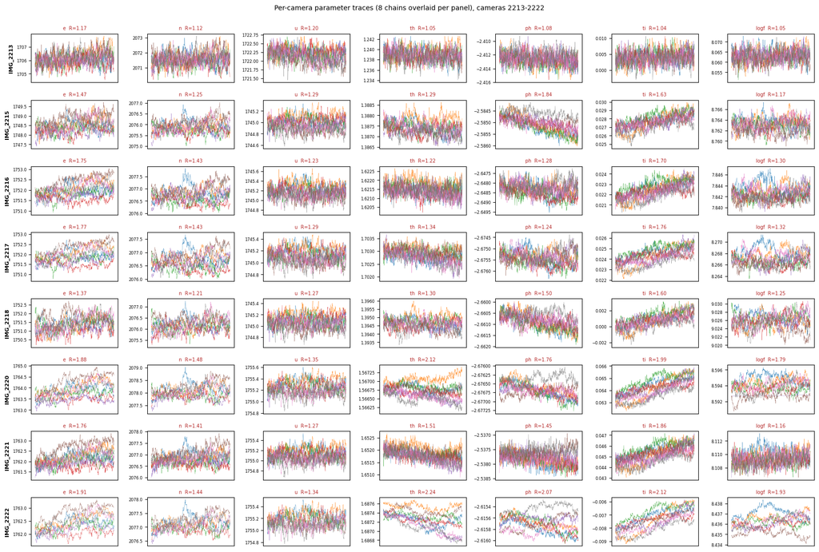

```python
THIN = max(1, ndraw // 700)   # ~700 plotted points per chain per panel

def trace_block(cam_keys, thin=THIN):
    nrow = len(cam_keys)
    fig, axs = plt.subplots(nrow, 7, figsize=(17, 1.45 * nrow), squeeze=False)
    for r, key in enumerate(cam_keys):
        base = keys.index(key) * 7
        for j, prm in enumerate(PRM):
            ax = axs[r, j]
            for c in range(nchain):
                ax.plot(np.arange(0, ndraw, thin), draws[c, ::thin, base + j],
                        lw=.35, alpha=.75, rasterized=True)
            ax.set_xticks([])
            ax.tick_params(labelsize=6)
            ax.set_title(f'{prm}  R={rhat[base+j]:.2f}', fontsize=7,
                         color=('firebrick' if rhat[base + j] > conv['thresholds']['rhat_max'] else 'black'))
            if j == 0:
                ax.set_ylabel(f'IMG_{key}', fontsize=8, fontweight='bold')
    fig.suptitle(f'Per-camera parameter traces ({nchain} chains overlaid per panel), '
                 f'cameras {cam_keys[0]}-{cam_keys[-1]}', fontsize=10)
    plt.tight_layout(rect=(0, 0, 1, 0.98))
    plt.show()

trace_block(keys[:8])
```

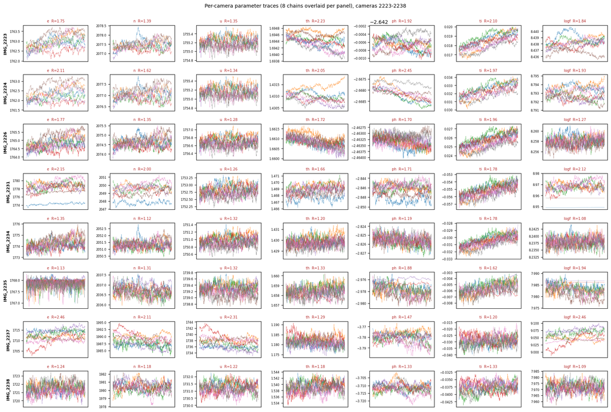

```python
trace_block(keys[8:16])
```

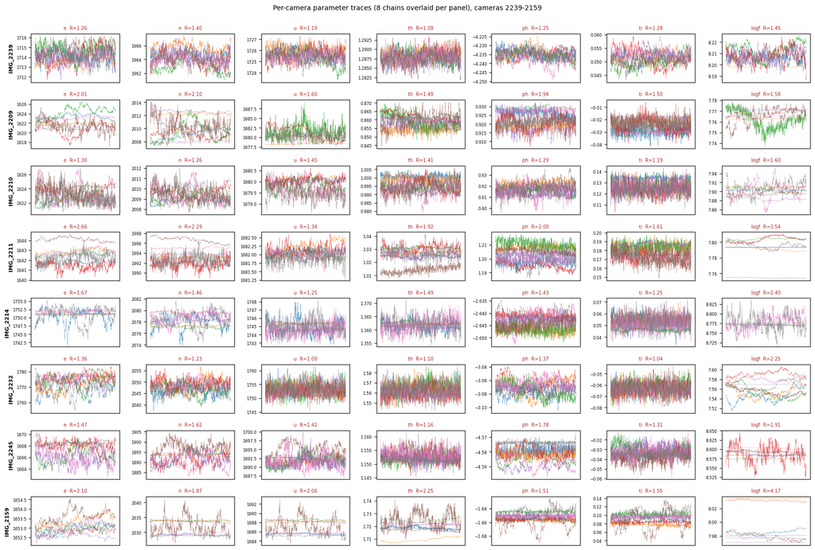

```python
trace_block(keys[16:24])
```

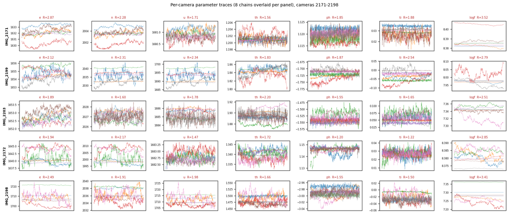

```python
if len(keys) > 24:
    trace_block(keys[24:])
```

## 5. Hillshade map with posterior E/N draws

Every camera's posterior draws in east-north space, on the hillshade DEM, with the antenna draws and the transmitter. This is the plot that shows whether the posterior is a tight cloud per camera or a smear, and how the camera network sits relative to the two targets.

Both targets are sampled here, so both carry draw clouds. The bracketed transmitter product (±1.5 m) is drawn as a circle for comparison — note how much tighter the posterior cloud is than that bracket, and see §3b and the caveats for why that tightness is not the same thing as accuracy.

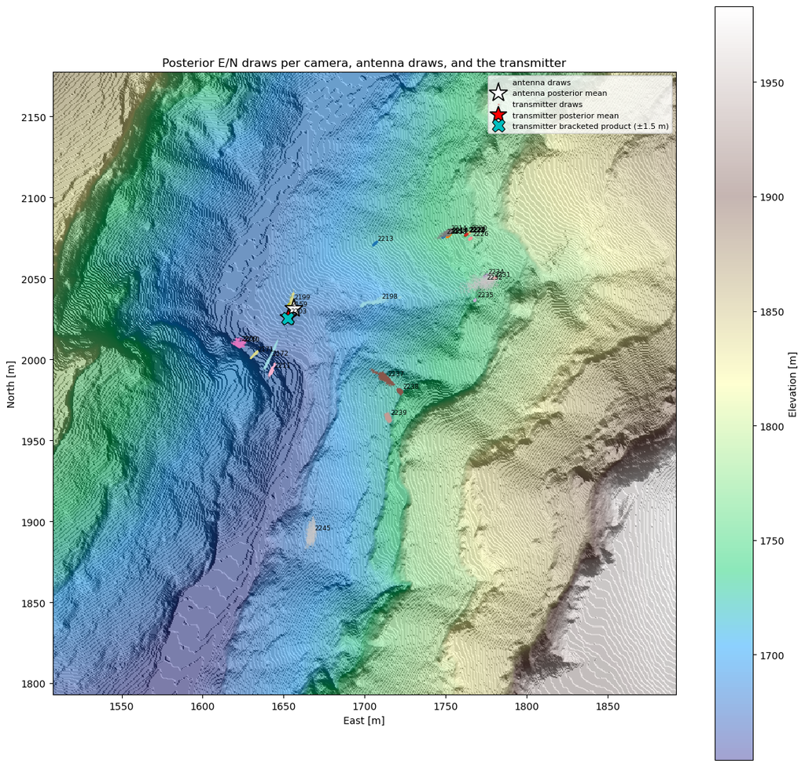

```python
from eigsep_terrain.marjum_dem import MarjumDEM as DEM
from marjum_bundle import working_grid
from terrain_hillshade_cmap import plot_terrain_hillshade
from matplotlib.patches import Circle

dem = working_grid(DEM(cache_file='marjum_dem_sw.npz'))
se, sn = dem._working_shift
dem_raw = DEM(cache_file='marjum_dem_sw.npz')

ant_mean = np.array(conv['antenna']['mean'])
shared = json.loads((WORKSPACE / 'v0001_marjum_geometry_snapshot' / 'shared.json').read_text())
tx_rec = shared['transmitter']['recommended_for_propagation']
tx_pos, tx_bound = np.array(tx_rec['position_enu_m']), tx_rec['bound_m']
tx_i = names.index('transmitter_e') if 'transmitter_e' in names else None
tx_mean = np.array(conv['transmitter']['mean']) if JOINT and 'transmitter' in conv else None

# Frame the map on everything we intend to draw.
cam_en = np.array([[draws[:, :, keys.index(k)*7].mean(), draws[:, :, keys.index(k)*7+1].mean()]
                   for k in keys])
allpts = np.vstack([cam_en, ant_mean[:2][None, :], tx_pos[:2][None, :]])
lo, hi = allpts.min(0) - 60, allpts.max(0) + 60
e0, n0 = (lo + hi) / 2
rng = float(max(hi - lo) / 2 + 40)

E_raw, N_raw, U_map = dem_raw.get_tile(erng_m=(e0 - se - rng, e0 - se + rng),
                                       nrng_m=(n0 - sn - rng, n0 - sn + rng), mesh=False)
E_map, N_map = E_raw + se, N_raw + sn

fig, ax = plt.subplots(figsize=(12, 11))
im = plot_terrain_hillshade(ax, U_map, res=float(dem.res),
                            extent=(E_map[0], E_map[-1], N_map[0], N_map[-1]))
fig.colorbar(im, ax=ax, label='Elevation [m]')

TH = max(1, ndraw // 300)
colors = plt.cm.tab20(np.linspace(0, 1, len(keys)))
for k, col in zip(keys, colors):
    b = keys.index(k) * 7
    e = draws[:, ::TH, b].ravel(); n = draws[:, ::TH, b + 1].ravel()
    ax.scatter(e, n, s=1.2, color=col, alpha=.35, linewidths=0, rasterized=True)
    ax.annotate(k, (e.mean(), n.mean()), fontsize=6.5, color='k',
                xytext=(3, 3), textcoords='offset points')

ax.scatter(draws[:, ::TH, ai].ravel(), draws[:, ::TH, ai + 1].ravel(),
           s=2.5, color='k', alpha=.5, linewidths=0, rasterized=True, label='antenna draws')
ax.plot(*ant_mean[:2], 'w*', ms=20, mec='k', mew=1.2, label='antenna posterior mean')
if tx_i is not None:
    ax.scatter(draws[:, ::TH, tx_i].ravel(), draws[:, ::TH, tx_i + 1].ravel(),
               s=2.5, color='tab:red', alpha=.5, linewidths=0, rasterized=True,
               label='transmitter draws')
    ax.plot(*tx_mean[:2], 'r*', ms=18, mec='k', mew=1.2, label='transmitter posterior mean')
ax.plot(*tx_pos[:2], 'cX', ms=13, mec='k', mew=.8, label=f'transmitter bracketed product (±{tx_bound} m)')
ax.add_patch(Circle(tx_pos[:2], tx_bound, fill=False, color='c', ls='--'))

ax.set_xlabel('East [m]'); ax.set_ylabel('North [m]'); ax.set_aspect('equal')
ax.set_title('Posterior E/N draws per camera, antenna draws, and the transmitter')
ax.legend(loc='best', fontsize=8)
plt.tight_layout(); plt.show()
```

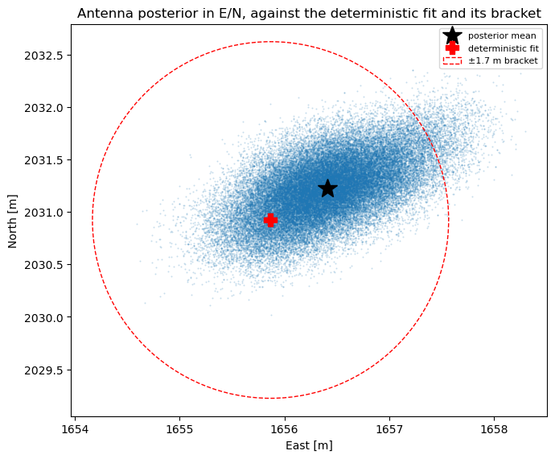

```python
# Zoom on the antenna cloud alone: at canyon scale the camera spread dominates
# and the antenna posterior is a dot, so its shape needs its own axes.
fig, ax = plt.subplots(figsize=(7, 6.5))
e = draws[:, :, ai].ravel(); n = draws[:, :, ai + 1].ravel()
ax.scatter(e, n, s=2, alpha=.25, color='tab:blue', linewidths=0, rasterized=True)
ax.plot(ant_mean[0], ant_mean[1], 'k*', ms=18, label='posterior mean')
ax.plot(det[0], det[1], 'rP', ms=12, label='deterministic fit')
ax.add_patch(Circle(det[:2], 1.7, fill=False, color='r', ls='--', label='±1.7 m bracket'))
ax.set_xlabel('East [m]'); ax.set_ylabel('North [m]'); ax.set_aspect('equal')
ax.set_title('Antenna posterior in E/N, against the deterministic fit and its bracket')
ax.legend(fontsize=8)
plt.tight_layout(); plt.show()
```

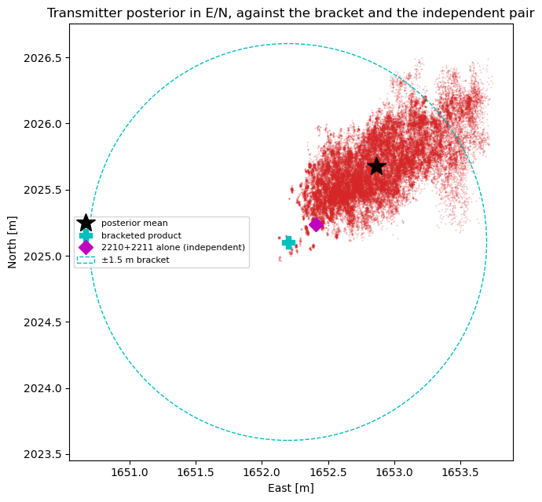

```python
if tx_i is not None:
    fig, ax = plt.subplots(figsize=(7, 6.5))
    e = draws[:, :, tx_i].ravel(); n = draws[:, :, tx_i + 1].ravel()
    ax.scatter(e, n, s=2, alpha=.25, color='tab:red', linewidths=0, rasterized=True)
    ax.plot(tx_mean[0], tx_mean[1], 'k*', ms=18, label='posterior mean')
    ax.plot(tx_pos[0], tx_pos[1], 'cP', ms=12, label='bracketed product')
    ax.plot(1652.410, 2025.238, 'mD', ms=9, label='2210+2211 alone (independent)')
    ax.add_patch(Circle(tx_pos[:2], tx_bound, fill=False, color='c', ls='--', label=f'±{tx_bound} m bracket'))
    ax.set_xlabel('East [m]'); ax.set_ylabel('North [m]'); ax.set_aspect('equal')
    ax.set_title('Transmitter posterior in E/N, against the bracket and the independent pair')
    ax.legend(fontsize=8)
    plt.tight_layout(); plt.show()
```